# Bibliometric Analysis on Amphibian Research

Maddison Howie

05/08/2022

# Main Questions

Here I analysed amphibian data from IUCN and screened publications from the Scopus database to answer the following questions relating to patterns and trends in amphibian research:

1. Is there a correlation between publication trend and land use?
2. Is there a geographical influence on amphibian research?
3. Are certain amphibian orders studied more than others?
4. Are amphibian species being studied based on their threatened status or population trend?

## Setup

The markdown document must be setup, packages are to be loaded and data imported.

## Data Organisation - Import and Clean

Data must be imported and organised appropriately so clean analysis can take place.

#### Amphibian Data from IUCN

```r
#import data downloaded from IUCN
IUCN <- read.csv(file = "/Users/rohanhowie/bibliometrics2022/Maddi/Data/IUCNsummary.csv", header=TRUE)

#remove unwanted columns
IUCN <- IUCN[c("scientificName","orderName","redlistCategory","populationTrend")]
```

#### Bibliographic Records from Rayyan (Screened)

*Import Records*

```r
#import included bibliographic records from Rayyan
screened <- read.csv("/Users/rohanhowie/bibliometrics2022/Maddi/Data/SpeciesLab.csv")
#dim(screened) #183 observations with 19 variables
```

*Prep and Merge with IUCN*

```r
#visualise export info, decisions and labels
screened$notes[1]

#filter rows that do not contain the string 'Included' or 'Maybe' in the notes column
screened %>% filter(!grepl('Excluded', notes)) %>% filter(!grepl('Maybe', notes)) -> screened_included
#dim(screened_included) #183 observations, 19 variables

#extract record labels from notes column - i.e. string after "RAYYAN-LABELS: "
screened_included$labels <- sub(".*RAYYAN-LABELS: ", "", screened_included$notes)

screened_included$labels[1:10] #view first 10 strings, should be formatted with labels separated

#split labels into individual species and place in a list
species_list <- str_split_fixed(screened_included$labels, ","  , 8)

#place species in a vector
species_list <- as.vector(species_list)
#remove the ""
species_list <- species_list[species_list != ""]
#need this? unique_list <- unique(species_list)
#table(species_list) #visualise the species frequencies

#convert species list into a data frame
species_df <- data.frame(table(species_list),stringsAsFactors = FALSE)
#rename species variable to 'scientificName' to easily merge with IUCN data frame
species_df <- rename(species_df, scientificName = species_list)
#rename Freq variable to 'PublicationFreq' for clarification
species_df <- rename(species_df, PublicationFreq = Freq)

#attempted to merge IUCN with species_df however there were species that had no data due to difference in scientific names

#rename species based on IUCN scientific name for consistency
species_df$scientificName <- recode(species_df$scientificName,
                                    'Bufo americanus' = 'Anaxyrus americanus',
                                    'Bufo calamita' = 'Epidalea calamita',
                                    'Eleutherodactylus diastema' = 'Diasporus diastema',
                                    'Eleutherodactylus fitzingeri' = 'Craugastor fitzingeri',
                                    'Feirana quadranus' = 'Nanorana quadranus',
                                    'Feirana taihangnica' = 'Nanorana taihangnica',
                                    'Hyla japonica' = 'Dryophytes japonicus',
                                    'Hyla microcephala' = 'Dendropsophus microcephalus',
                                    'Hyla rosenbergi' = 'Boana rosenbergi',
                                    'Hyla versicolor' = 'Dryophytes versicolor',
                                    'Leptodactylus tibialis' = 'Leptodactylus fragilis',
                                    'Mesotriton alpestris' = 'Ichthyosaura alpestris',
                                    'Rana clamitans' = 'Lithobates clamitans',
                                    'Rana pipiens' = 'Lithobates pipiens',
                                    'Rana sylvatica' = 'Lithobates sylvaticus',
                                    'Rhinella schneideri' = 'Rhinella diptycha',
                                    'Triturus vulgaris' = 'Lissotriton vulgaris')

#merge IUCN species with species_df (species form publications)
species_IUCN <- full_join(IUCN, species_df, by="scientificName")

#replace NAs with 0 in frequency column
species_IUCN$PublicationFreq[is.na(species_IUCN$PublicationFreq)] <- 0

#'Feirana kangxianensis' has not been listed under IUCN yet as it a new species. Fill in information manually
species_IUCN[7301, 2] = "ANURA"
species_IUCN[7301, 3] = "Data Deficient"
species_IUCN[7301, 4] = "Data Deficient"

#remove multiple species column for clear visualization of data and comparison
species_IUCN <- species_IUCN[-c(7302), ]

#change format of order names to match studied species (scopus) data frame
species_IUCN$orderName[species_IUCN$orderName=="ANURA"] <- "Anura"
species_IUCN$orderName[species_IUCN$orderName=="CAUDATA"] <- "Caudata"
species_IUCN$orderName[species_IUCN$orderName=="GYMNOPHIONA"] <- "Gymnophiona"
```

#### Import Bibliographic Records from Scopus (Not Screened)

*Import Records*

```r
#import bibliographic records from Scopus and convert to a bibliometric data frame
bib <- convert2df("/Users/rohanhowie/bibliometrics2022/Maddi/Data/AmphScopus.bib", dbsource = "scopus", format = "bibtex")
#dim(bib) #771 observations with 40 variables
```

#### Prep and Merge Screened and Bibliographic Records from Scopus

*Prep Records from Rayyan (Screened) for Merging*

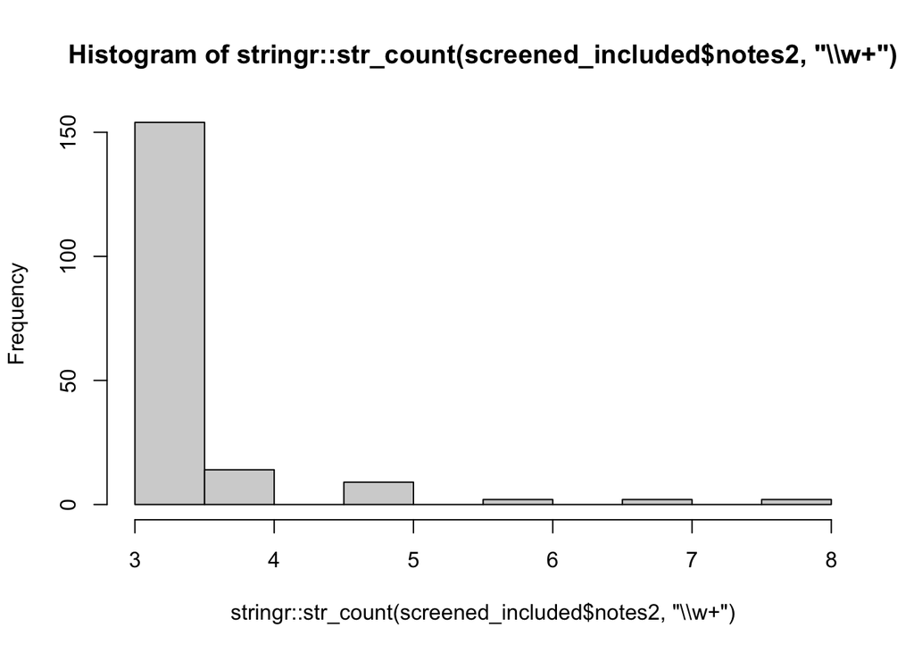

```r
#Separate labels for bibliometric coupling data
screened_included$notes2 <- gsub("Cited.*2022 | RAYYAN-INCLUSION: \\{\"z5297814\"=>\"Included\"\\} | " , "", screened_included$notes) #remove text between "Cited" and first inclusion label
screened_included$notes2[1] #visualise line data
screened_included$notes2 <- gsub("ExportDate:30June2022", "", screened_included$notes2) #remove extra field present in a few records
screened_included$notes2 <- gsub("\\|\\|RAYYAN-LABELS:", ",", screened_included$notes2) #remove extra field present in a few records
screened_included$notes2 <- sub(",", "", screened_included$notes2) #remove first comma
screened_included$notes2[1] #visualise line data

#using stringr package functions for further processing:
#check numbers of labels per record
max(stringr::str_count(screened_included$notes2, "\\w+"))
hist(stringr::str_count(screened_included$notes2, "\\w+"))
```

```r
#Split vector into individual labels
stringr::str_split(string = screened_included$notes2, pattern = ",") #this splits at "," and creates a list
```

*Merge Screened Records with Bibliographic Records from Scopus*

```r
#before joining the data frames by title, need to tidy up titles

# Removing all punctuation and extra white spaces in bib object, in order to compare dataframes by Title:
bib$TI2 <- str_replace_all(bib$TI,"[:punct:]","") %>% str_replace_all(.,"[ ]+", " ")

# Remove all punctuation and extra white spaces in screened_included object, in order to compare dataframes by Title:
screened_included$TI2 <- str_to_upper(str_replace_all(screened_included$title,"[:punct:]","")) %>% str_replace_all(.,"[ ]+", " ")

# The field 'TI2' will now be used for merging info from onto bib data frame
bib_title <- left_join(bib, screened_included %>% dplyr::select(url, title, TI2, year, journal,  notes2), by = "TI2")
table(is.na(bib_title$notes2)) #182 records with labels, these were included

#only keep rows with labels
bib_title %>% filter(!is.na(notes2)) -> bib_title_included
dim(bib_title_included) #182 records included
table(bib_title_included$notes2)
names(bib_title_included)

#Analysed 182 records that came from Scopus.
```

*Separate Publication Labels*

```r
#split publication labels and form a matrix
splitlabels <- str_split_fixed(bib_title_included$notes2, ",", 8)
#convert matrix to a data frame
splitdf <- as.data.frame(splitlabels)

#swap values incorrectly screened in Rayyan
splitdf[2, 1] = "Amphibia"
splitdf[2, 2] = "Mining"
splitdf[14, 1] = "Anura&Caudata"
splitdf[14, 2] = "Mining"
splitdf[22, 1] = "Amphibia"
splitdf[22, 2] = "Logging"
splitdf[51, 1] = "Anura&Caudata"
splitdf[51, 2] = "Agriculture"
splitdf[99, 1] = "Caudata"
splitdf[99, 2] = "Mining"
splitdf[104, 1] = "Anura&Caudata"
splitdf[104, 2] = "Logging"
splitdf[143, 1] = "Anura&Caudata"
splitdf[143, 2] = "Urbanisation"
splitdf[144, 1] = "Anura&Caudata"
splitdf[144, 2] = "Deforestation"
splitdf[151, 1] = "Anura&Caudata"
splitdf[151, 2] = "Fragmentation"
splitdf[159, 1] = "Anura&Caudata"
splitdf[159, 2] = "Agriculture"
splitdf[161, 1] = "Anura&Caudata"
splitdf[161, 2] = "Urbanisation"

#combine label df with original df
bib_coup <- bind_cols(bib_title_included, splitdf)

#rename order variable
bib_coup <- rename(bib_coup, orderName = V1)
#rename cause variable
bib_coup <- rename(bib_coup, cause = V2)
#reorder amphibian groups for consistency
bib_coup$orderName <- factor(bib_coup$orderName, levels = c("Anura", "Caudata", "Anura&Caudata", "Amphibia"))
```

## Data Analysis and Visualisation

Here plots will be created to visualise the data in an attempt to answer the four questions mentioned at the beginning of this document.

```r
#set general plot parameters
plot.themes <- theme(
  plot.title = element_text(family = "Arial", size = (13), hjust = 0.5),
  axis.title = element_text(family = "Arial", face = "bold", size = (10), colour = "black"),
  axis.text = element_text(family = "Arial", colour = "black", size = (10))
) #set title and label factors
```

#### Publication Trend

```r
#plot publications across time separated by order

jpeg("publicationtrend.jpg") # open a jpg file for saving

trend.plot <- ggplot(bib_coup, aes(x=PY, col = orderName)) +
  stat_count(geom='line', aes(y=..count..)) +
  xlim(1987, 2022) +
  plot.themes +
  labs(title="Amphibian Publication Trend by Order", y = "Publications", x = "Year", col = "Order") +
  scale_color_manual(values=c("#99CC00", "#FF9900", "#66CCCC", "#FF3399")) +
  theme_bw() +
  theme(legend.position="bottom", panel.border = element_blank(), panel.grid.major = element_blank(), panel.grid.minor = element_blank(), axis.line = element_line(colour = "black"))

trend.plot + plot.themes #plot with themes

dev.off() #close jpg file
```

#### Geographical Productivity

*Map of Publications by Country*

```r
#extract countries from the affiliations by ;
bib_cc <- metaTagExtraction(bib_coup, Field = "AU_CO", sep = ";")

#remove countries with longitude >180 to make equal projection-like map without artifacts
world_map <- map_data("world") %>%
  filter(! long > 180
  )
# Format country names to match regions on the world map
bib_cc$region <- str_to_title(bib_cc$AU_CO)

#need to split region column
region <- str_split_fixed(bib_cc$region, ";", 12)
regiondf <- as.data.frame(region)

#split labels into individual countries
region <- str_split_fixed(bib_cc$region, ";", 12)

#put species into a vector
region.vec <- as.vector(region)
region.vec
#remove the ""
region.vec <- region.vec[region.vec != ""]
#table(region.vec) #visualise the species frequencies
#convert table to a data frame
region.vec.df <- data.frame(table(region.vec),stringsAsFactors = FALSE)
region.vec.df

#rename country variables from region.vec
region.vec.df <- rename(region.vec.df, region = region.vec)
region.vec.df <- rename(region.vec.df, n = Freq)

#rename Usa to USA and United Kingdom to UK for consistency
region.vec.df$region <- recode(region.vec.df$region, 'Usa' = 'USA')
region.vec.df$region <- recode(region.vec.df$region, 'United Kingdom' = 'UK')

#create table with all counts as 0 to form an empty map
emptymap <- tibble(region = unique(world_map$region), n = rep(0,length(unique(world_map$region))))

#join table with actual counts table
fullmap <- left_join(emptymap, region.vec.df, by = "region")
#make new column for fixed counts
fullmap$n <- fullmap$n.x + fullmap$n.y
#change NA to 0 for regions with no counts
fullmap$n[is.na(fullmap$n)] <- 0
```

```r
jpeg("publicationdistribution.jpg") # open a jpg file for saving

#formulate map showing publications by country
map <- fullmap %>%
  ggplot(aes(fill = n, map_id = region)) +
  geom_map(map = world_map) +
  expand_limits(x = world_map$long, y = world_map$lat) +
  coord_map("moll") +
  theme_bw() +
  theme(legend.position="bottom", axis.text.x=element_blank(),
        axis.ticks.x=element_blank(), axis.title.x=element_blank(),
        axis.text.y=element_blank(),
        axis.ticks.y=element_blank(), axis.title.y=element_blank(), plot.title = element_text(hjust = 0.5)) +
   scale_fill_viridis(direction=-1, option="viridis", breaks=c(25,50,75,100,125,150), limits = c(1, 140), guide = guide_colorbar(direction = "vertical.")) +
  guides(fill = guide_colourbar(barwidth = unit(10, units = "cm"), barheight = unit(10, units = "mm"))) + labs(fill="Number of \nPublications", title = "Distribution of Publications by Countries")

map #plot

dev.off() #close jpef file for saving
```

*Country Collaboration*

```r
#Plot a chord diagram showing country collaboration:

#convert extracted countries (extracted on line 266) into a matrix
NetMatrix <- biblioNetwork(bib_cc, analysis = "collaboration", network = "countries", sep = ";")

results <- biblioAnalysis(bib_cc, sep = ";")
#select for top 20 countries
S2 <- summary(object = results, k = 20 ,pause = FALSE)
#extract names of countries
MostProdCountries <- S2$MostProdCountries
#change column to numeric
MostProdCountries$Articles <- as.numeric(MostProdCountries$Articles)
#save list of names of top 7 countries in a vector
countries <- MostProdCountries[1:7,'Country']
#remove white space after country name
countries <- trimws(countries)

#convert counts to numeric matrix
net_matrix <- as.matrix(NetMatrix)
#reduce matrix to the list of top countries
small_matrix <- net_matrix[countries, countries]
#diag(small_matrix) <- 0 #can remove collaboration with same country
#remove lower triangle as this is a duplication of information
small_matrix[lower.tri(small_matrix)] <- 0
```

```r
jpeg("countrychord.jpg") # open a jpeg file for saving

#use circos.clear() to reset circular layout parameters i.e. prep for plotting
circos.clear()
#plot country collaboration
chordDiagramFromMatrix(small_matrix, grid.col = c("#330066", "#CC6699", "#FF9966", "#33CCFF", "#339999", "#33CC99", "#CCFF00"), title("Collaboration between Most Productive Countries"))

dev.off () #close the jpeg file
```

#### Order Proportions

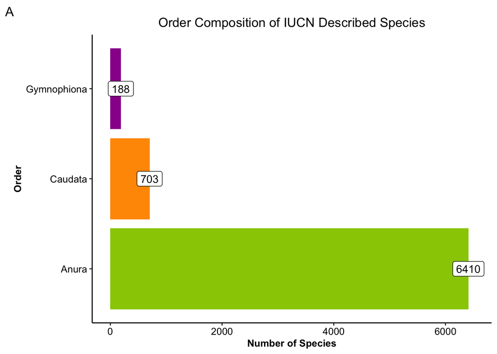

```r
#plot order proportions among IUCN described species:

#reorder amphibian groups for consistency
species_IUCN$orderName <- factor(species_IUCN$orderName, levels = c("Anura", "Caudata", "Gymnophiona", "Amphibia"))

#create plot
described.proportion <- ggplot(data=species_IUCN) +
  geom_bar(aes(x= orderName, fill=orderName), show.legend = FALSE) +
  ylim(0, 6500) +
  geom_label(aes(x=orderName,label=..count..),stat='count') +
  plot.themes + labs(tag = "A", fill="Order", title = "Order Composition of IUCN Described Species", y = "Number of Species", x = "Order") +
  scale_fill_manual(values = c("#99CC00", "#FF9900", "#990099")) +
  theme_bw() +
  theme(panel.border = element_blank(), panel.grid.major = element_blank(), panel.grid.minor = element_blank(), axis.line = element_line(colour = "black")) +
  coord_flip()

#plot with themes
described.proportion + plot.themes
```

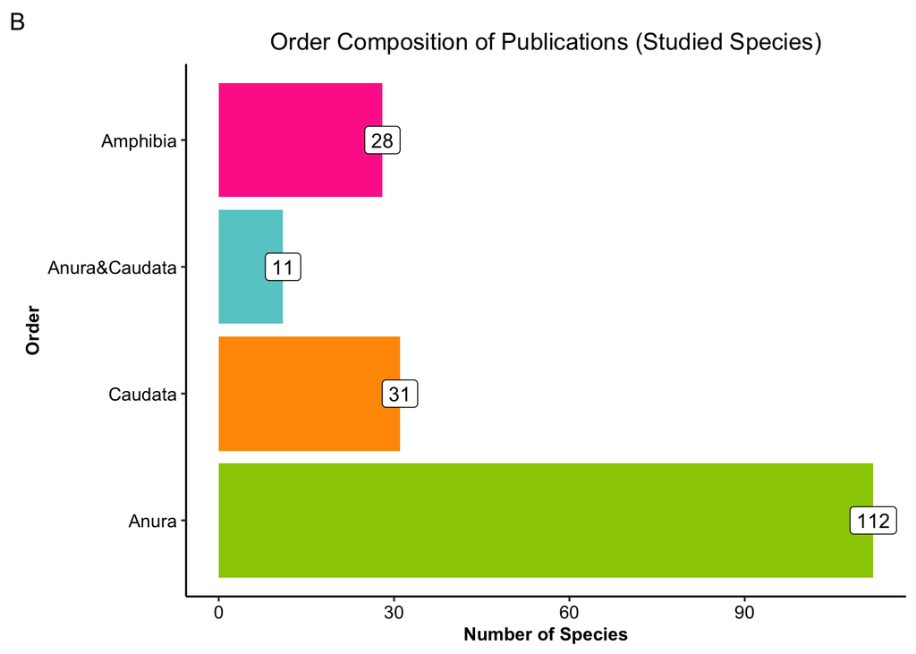

```r
#plot order proportions among species studied in publications:

#create plot
studied.proportion <- ggplot(data=bib_coup) +
  geom_bar(aes(x= orderName, fill=orderName), show.legend = FALSE) +
  theme(legend.position="none") +
  geom_label(aes(x= orderName,label=..count..), stat='count') +
  plot.themes +
  labs(tag = "B", fill="Order", title = "Order Composition of Publications (Studied Species)", y = "Number of Species", x = "Order") +
  scale_fill_manual(values = c("#99CC00", "#FF9900", "#66CCCC", "#FF3399")) +
  theme_bw() +
  theme(panel.border = element_blank(), panel.grid.major = element_blank(), panel.grid.minor = element_blank(), axis.line = element_line(colour = "black")) + coord_flip()

#plot with themes
studied.proportion + plot.themes
```

```r
#Use patchwork package to merge proportion plots of described and studied species:

jpeg("speciesnumbers.jpg") # open a jpeg file for saving

patchwork1 <- described.proportion / studied.proportion
patchwork1 + plot_annotation(
  title = 'Amphibian Order Composition in Described vs. Studied Species')

dev.off() #close the jpeg to save
```

#### Order Compositions - Threatened Status and Population Trend

*Visualise Order Composition based on Threatened Status*

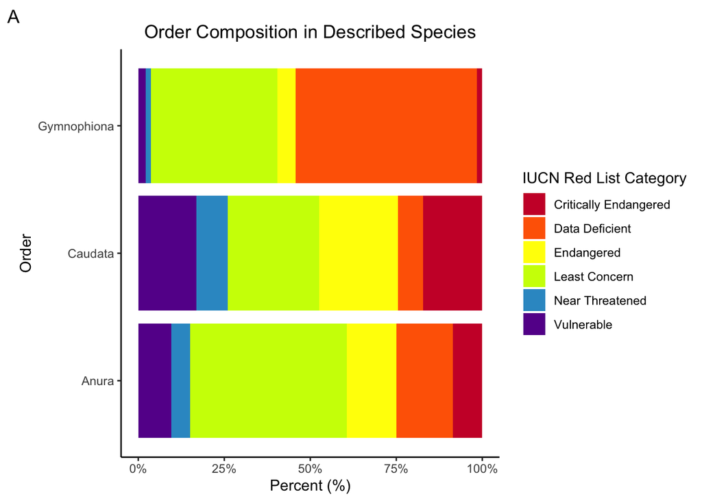

```r
species_IUCN <- subset(species_IUCN, !(redlistCategory %in% c("Extinct", "Extinct in the Wild"))) #this keeps all rows where the redlistCategory is not "Extinct" or "Extinct in the Wild"

#need to remove all with 0 frequency - limit to only those found in publications
speciesinpub <- subset(species_IUCN, PublicationFreq != "0")
view(speciesinpub)
#set plot themes

speciesinpub$redlistCategory <- factor(speciesinpub$redlistCategory, levels = c("Critically Endangered", "Endangered", "Vulnerable", "Near Threatened", "Least Concern", "Data Deficient")) #reorder categories for consistency

speciesinpub$orderName <- factor(speciesinpub$orderName, levels = c("Anura", "Caudata", "Gymnophiona", "Amphibia")) #reorder amphibian groups for consistency

threatened.IUCN <- ggplot(species_IUCN, aes(orderName, fill=redlistCategory)) + geom_bar(position='fill') + scale_y_continuous(labels = scales::percent) + labs(tag = "A", title = "Order Composition in Described Species", y = "Percent (%)", x = "Order") + labs(fill='IUCN Red List Category') + scale_fill_manual(values = c("#CC0033", "#FF6600", "#FFFF00", "#CCFF00", "#3399CC", "#660099")) + theme_bw() + theme(plot.title=element_text(hjust=0.5), panel.border = element_blank(), panel.grid.major = element_blank(), panel.grid.minor = element_blank(), axis.line = element_line(colour = "black")) +coord_flip()  #plot of threatened status among orders

threatened.IUCN
```

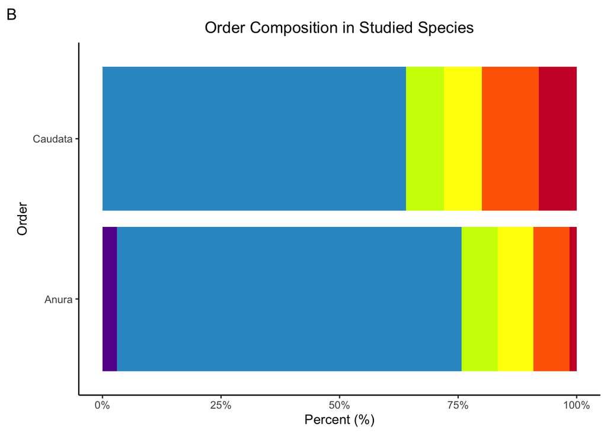

```r
threatened.stacked <- ggplot(speciesinpub, aes(orderName, fill=redlistCategory)) + geom_bar(position='fill') + scale_y_continuous(labels = scales::percent) + labs(tag = "B", title = "Order Composition in Studied Species", y = "Percent (%)", x = "Order") + labs(fill='IUCN Red List Category') + scale_fill_manual(values = c("#CC0033", "#FF6600", "#FFFF00", "#CCFF00", "#3399CC", "#660099")) + theme_bw() + theme(legend.position = "none", plot.title=element_text(hjust=0.5), panel.border = element_blank(), panel.grid.major = element_blank(), panel.grid.minor = element_blank(), axis.line = element_line(colour = "black")) + coord_flip()

threatened.stacked #plot of threatened status among orders
```

```r
#Use patchwork package to merge threatened status plots for described and studied species:

jpeg("redlist.jpg") # open a jpeg file for saving

patchwork2 <- threatened.IUCN / threatened.stacked
patchwork2 + plot_annotation(
  title = 'Order Composition of Described vs. Studied Species \nbased on IUCN Red List Category')

dev.off() #close the jpeg file to save
```

*Visualise Order Composition based on Population Trend*

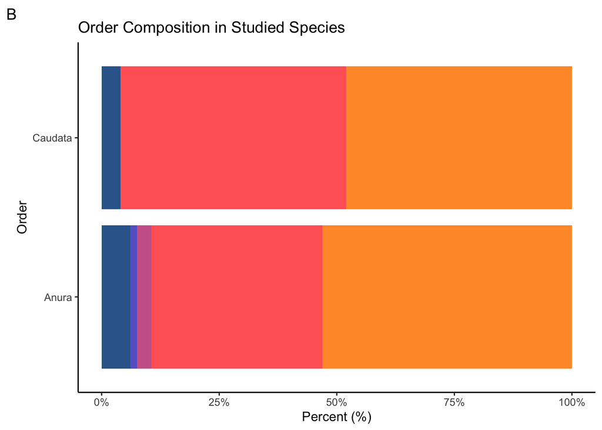

```r
#need to fix blank cells
species_IUCN$populationTrend[species_IUCN$populationTrend==""] <- "Unknown" #change blanks to 'Unknown' - these are most likely 'unspecified' on the IUCN website

speciesinpub$populationTrend <- factor(speciesinpub$populationTrend, levels = c("Decreasing", "Stable", "Increasing", "Data Deficient", "Unknown")) #reorder population trend categories for consistency

population.stacked <- ggplot(speciesinpub, aes(orderName, fill=populationTrend)) + geom_bar(position='fill') + scale_y_continuous(labels = scales::percent) + labs(tag = "B", title = "Order Composition in Studied Species", y = "Percent (%)", x = "Order") + labs(fill='Population Trend') + scale_fill_manual(values = c("#FF9933", "#FF6666", "#CC6699", "#6666CC", "#336699"))  + theme_bw() + theme(legend.position = "none", panel.border = element_blank(), panel.grid.major = element_blank(), panel.grid.minor = element_blank(), axis.line = element_line(colour = "black")) + coord_flip()

population.stacked    #plot of threatened status among orders
```

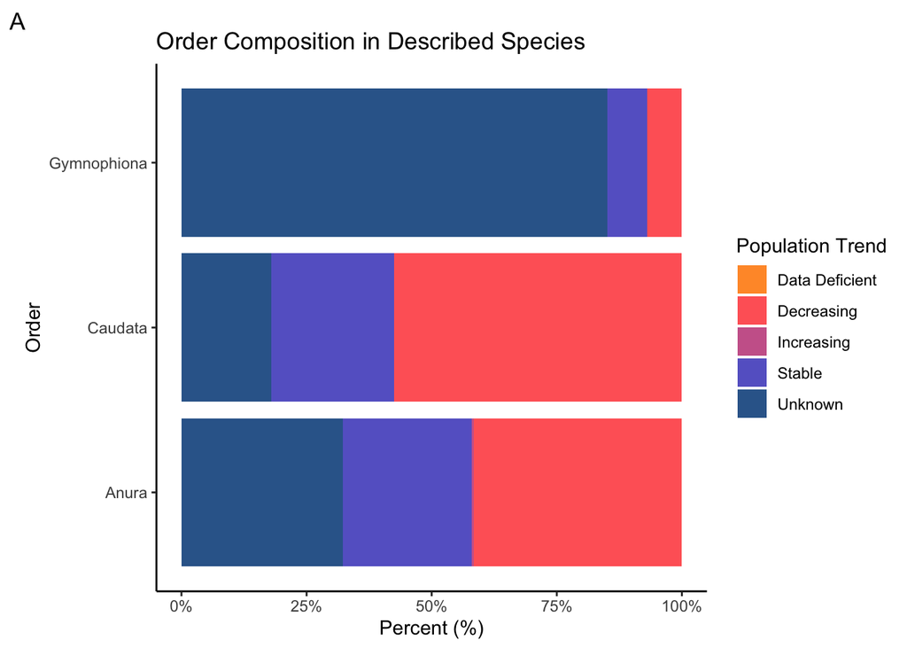

```r
population.IUCN <- ggplot(species_IUCN, aes(orderName, fill=populationTrend)) + geom_bar(position='fill') + scale_y_continuous(labels = scales::percent) + labs(tag = "A", title = "Order Composition in Described Species", y = "Percent (%)", x = "Order") + labs(fill='Population Trend') + scale_fill_manual(values = c("#FF9933", "#FF6666", "#CC6699", "#6666CC", "#336699")) + theme_bw() + theme(panel.border = element_blank(), panel.grid.major = element_blank(), panel.grid.minor = element_blank(), axis.line = element_line(colour = "black")) + coord_flip()  #plot of threatened status among orders

population.IUCN
```

```r
#Use patchwork package to merge population trend plots for described and studied species:

jpeg("poptrend.jpg") # open a jpeg file for saving

patchwork3 <- population.IUCN / population.stacked
patchwork3 + plot_annotation(
  title = 'Order Composition of Described vs. Studied Species \nbased on IUCN Population Trend')

dev.off() #close jpeg file to save
```

#### Keyword Analyses

*Keyword Co-occurrence*

```r
#plot chord diagram of keyword co-occurrences in publications:

#remove general keywords including 'amphibia', 'amphibian', and 'brazil'.
bib_coup$ID <-gsub("AMPHIBIA; ","",as.character(bib_coup$ID))
bib_coup$ID <-gsub("AMPHIBIAN; ","",as.character(bib_coup$ID))
bib_coup$ID <-gsub("BRAZIL; ","",as.character(bib_coup$ID))

#extract keywords from affiliation
bib_term <- metaTagExtraction(bib_coup, Field = "AU_DE", sep = ";")
#convert into a matrix
NetMatrix2 <- biblioNetwork(bib_term, analysis = "co-occurrences", network = "keywords", sep = ";")

results <- biblioAnalysis(bib_term, sep = ";")
#select for top 10 keywords
top10 <- summary(object = results, k = 10 ,pause = FALSE)
#extract keywords
most.common.terms <- top10$MostRelKeywords
#change column to numeric
most.common.terms$Articles <- as.numeric(most.common.terms$Articles)
#save list of keywords in a vector
terms <- most.common.terms[1:10, 3]
#remove white space after keyword
terms <- trimws(terms)

#convert counts to numeric matrix
net_matrix2 <- as.matrix(NetMatrix2)
#reduce matrix to the list of top keywords
term_matrix <- net_matrix2[terms, terms]
#diag(small_matrix) <- 0 #can remove occurrence with the same word
#remove lower triangle as this is a duplication of information
term_matrix[lower.tri(term_matrix)] <- 0
```

```r
jpeg("keywords.jpg") # open a jpeg file for saving

#use circos.clear() to reset circular layout parameters i.e. prep for plotting
circos.clear()
#set colour parameters for chord diagram
mycolour <- viridis(10, alpha = 1, begin = 0, end = 1, option = "C")
mycolour <- mycolour[sample(1:10)]
#set text size and margin parameters
par(cex = 0.5, mar = c(0, 0, 2, 0))

#plot top 10 keywords co-occurrence

chordDiagramFromMatrix(term_matrix, annotationTrack = "grid", preAllocateTracks = 1, grid.col = mycolour, title("Top 10 Keyword Co-Occurrences"))
circos.trackPlotRegion(track.index = 1, panel.fun = function(x, y) {
  xlim = get.cell.meta.data("xlim")
  ylim = get.cell.meta.data("ylim")
  sector.name = get.cell.meta.data("sector.index")
  circos.text(mean(xlim), ylim[1] + .1, sector.name, facing = "clockwise", niceFacing = TRUE, adj = c(0, 0.5))
  circos.axis(h = "bottom", labels.cex = 1, major.tick.length = 0.1, sector.index = sector.name, track.index = 2)
}, bg.border = NA)

dev.off() #close the jpeg file to save
```

*Keyword Growth Over Time*

```r
data(scientometrics, package = "bibliometrixData")

# select top 10 keywords for growth analysis
topKW=KeywordGrowth(bib_coup, Tag = "ID", sep = ";", top=10, cdf=TRUE)
KW.growth=melt(topKW, id='Year')
#rename 'variable' to 'Keyword' for reading ease
KW.growth <- rename(KW.growth, Keyword = variable)
```

```r
jpeg("growthplot.jpg") # open a jpeg file for saving

#create line plot showing keyword occurrence in publications along time
growth.plot <- ggplot(KW.growth,aes(Year,value, group=Keyword, color=Keyword)) +
  geom_line() +
  plot.themes +
  labs(fill="Keyword", title="Growth of Top 10 Keywords in Publications", y = "Keyword Occurrence", x = "Year") +
  theme_bw() +
  theme(legend.position="bottom", legend.key.width = unit(0.5, 'cm'), legend.key.height = unit(0.8,'cm'), legend.text = element_text(size=6), panel.border = element_blank(), panel.grid.major = element_blank(),  panel.grid.minor=element_blank(), axis.line = element_line(colour="black"), plot.title = element_text(hjust = 0.5))

#plot graph with each keyword discretely coloured
growth.plot + scale_colour_discrete(labels = function(x) str_wrap(x, width = 3))

dev.off() #close jpeg file to save
```

#### Research Topics

```r
#add space in between ModifiedWaterbodies for clarity on plot
bib_coup$cause[bib_coup$cause=="ModifiedWaterbodies"] <- "Modified Waterbodies"

jpeg("topics.jpg") # open a jpeg file for saving

#bar plot of habitat loss causes based on the number of publications that focused on each
cause.plot <- ggplot(data=bib_coup) +
  geom_bar(aes(x= cause, fill=cause)) +
  theme_bw() +
  theme(legend.position="none", panel.border = element_blank(), panel.grid.major = element_blank(), panel.grid.minor = element_blank(), axis.line = element_line(colour = "black")) +
  geom_label(aes(x= cause,label=..count..), stat='count')

#print plot with themes and title names
cause.plot +
  plot.themes +
  labs(title = "Habitat Loss Cause in Publications", y = "Number of Publications", x = "Cause of Habitat Loss") +
  coord_flip()

dev.off() #close the jpeg file to save
```